# Flatten the Cruve by social distancing - a tutorial followed

Inspired by https://flowingdata.com/2020/03/18/how-to-flatten-the-curve-a-social-distancing-simulation/  
**Will make an R Shiny app with a more complicated model**  
User could choose the social distance rate (`act.rate`), how well people wear masks/wash hands (`inf.pro`), how many people vaccinated (assuming vaccination render people faster recovery and permanent immunity, `rec.rate`)

### Load packages neeeded

We will need `EpiModel`,`extrafont`, and `animation`.  
http://www.epimodel.org/

### Try a similuation utilizing Susceptible-Infectious-Recovred Model

```r
param <- param.dcm(inf.prob = 0.2, act.rate = 1, rec.rate = 1/20,
                   a.rate = 0, ds.rate = 0, di.rate = 1/80, dr.rate = 0)
```

Set our initial population with 1,000 susceptible people, 1 infected, and 0 recovered

```r
init <- init.dcm(s.num = 1000, i.num = 1, r.num = 0)
```

controls for the “Deterministic Compartmental Model”  
We will run a SIR model and run the simulation 1000 times in 0.5 time unit increments

```r
control <- control.dcm(type = "SIR", nsteps = 1000, dt = 0.5)
```

Run the model and transform the data

```r
mod <- dcm(param, init, control)
mod.df <- as.data.frame(mod)
```

### Plot the data

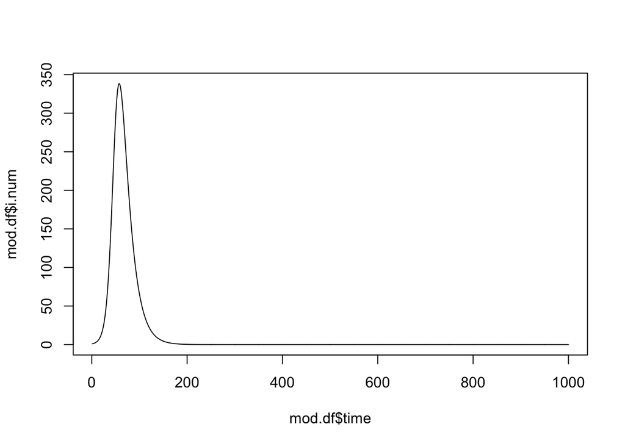

```r
plot(mod.df$time, mod.df$i.num, type="l")
```

set up a blank plot

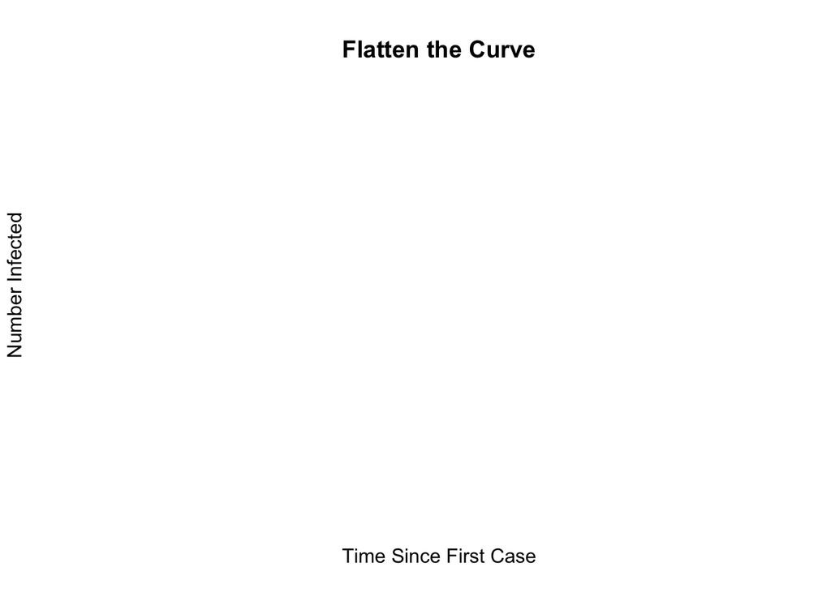

```r
plot(NA, type="n", xlim=c(0,1000), ylim=c(0, 250),
     bty="n", axes=FALSE,
     xlab="Time Since First Case", ylab="Number Infected",
     main="Flatten the Curve")
```

Set the act.rates range

```r
act.rates <- seq(.8, 0, by=-.05)
```

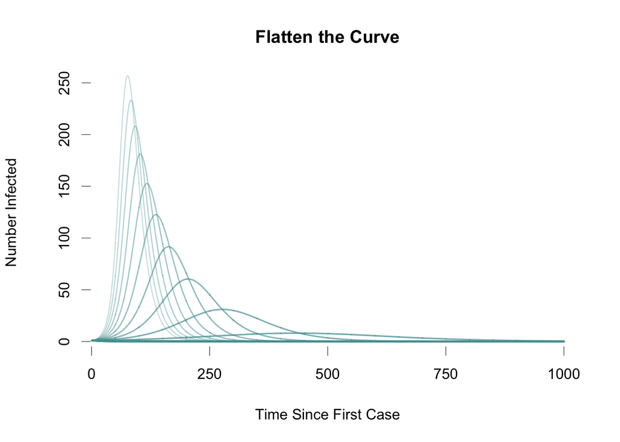

```r
# Start with a blank plot
plot(NA, type="n", xlim=c(0,1000), ylim=c(0, 250),
     bty="n", axes=FALSE,
     xlab="Time Since First Case", ylab="Number Infected",
     main="Flatten the Curve")
#Draw axis
axis(1, seq(0,1000,250), lwd=0, lwd.ticks = .5, pos = -5)
axis(2, at=seq(0, 250, 50), lwd=0, lwd.ticks=.5, pos=-2)
# Run simulation on each act.rate
for (rt in act.rates) {
    param <- param.dcm(inf.prob = 0.2, act.rate = rt, rec.rate = 1/20,
                       a.rate = 0, ds.rate = 0, di.rate = 1/80, dr.rate = 0)
    mod <- dcm(param, init, control)
    mod.df <- as.data.frame(mod)
    lines(mod.df$time, mod.df$i.num,
          col=rgb(85/255,158/255,161/255,min(1-rt+.1, 1)),
          lwd=1+(1-rt))
}
```

## Try the same simulation on the inf.pro

```r
init <- init.dcm(s.num = 10000, i.num = 1, r.num = 0)
control <- control.dcm(type = "SIR", nsteps = 10000, dt = 0.5)
```

https://www.mpic.de/4747065/risk-calculation?c=3538502  
A model in the above study characterize the senario which a school class with no safety measures taken => 25 young students with 6 hrs of class and one student with COVID  
The probability of one particular person to be infected is 0.1  
The probability that anyone wil be infected is 0.9  
I will use 0.1 to simulate the situation when prevention methods such as masks and hand washing are enforced

```r
inf.probs <- seq(.1, 0, by=-.01)
```

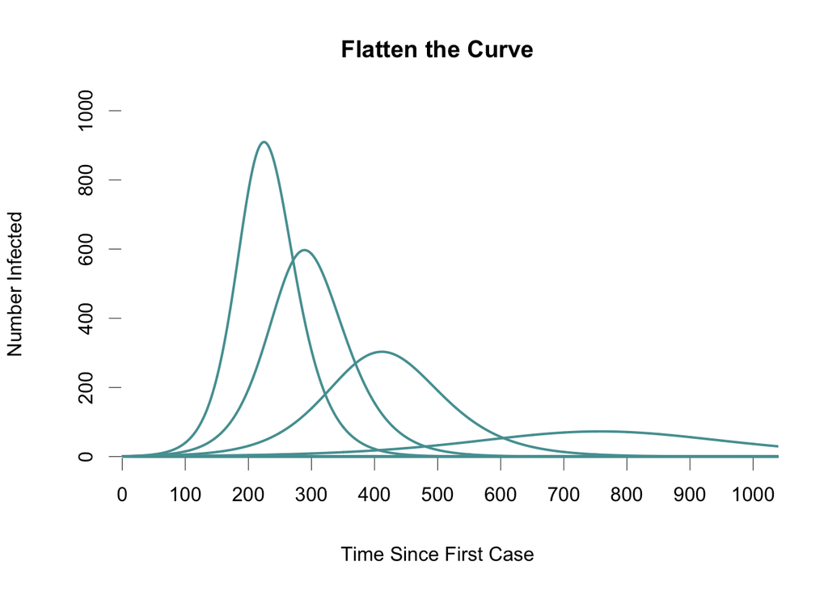

```r
# Start with a blank plot
plot(NA, type="n", xlim=c(0,1000), ylim=c(0, 1000),
     bty="n", axes=FALSE,
     xlab="Time Since First Case", ylab="Number Infected",
     main="Flatten the Curve")
#Draw axis
axis(1, seq(0,1000,100), lwd=0, lwd.ticks = .5, pos = -5)
axis(2, at=seq(0, 1000, 200), lwd=0, lwd.ticks=.5, pos=-2)
# Run simulation on each act.rate
for (inf.p in inf.probs) {
    param <- param.dcm(inf.prob = inf.p, act.rate = 1, rec.rate = 1/20,
                       a.rate = 0, ds.rate = 0, di.rate = 1/80, dr.rate = 0)
    mod <- dcm(param, init, control)
    mod.df <- as.data.frame(mod)
    lines(mod.df$time, mod.df$i.num,
          col=rgb(85/255,158/255,161/255,min(1-rt+.1, 1)),
          lwd=1+(1-rt))
}
```